# Inferential Analyses

Dan W Joyce

10th October 2018

# 1 Setup

Before executing this notebook, check `./DerivedData` for:

- `survivalData_tabulated.csv`

Check that you’re working directory is `./Code/`

```r
rm( list = ls() )
require(dplyr)
require(knitr)
require(kableExtra)
require(reshape2)
require(ggplot2)
require(boot)
require(parallel)
require(mice)
require(tibble)
require(rms)
options(knitr.kable.NA = '')
tabSurv <- read.csv("../DerivedData/survivalData_tabulated.csv")
startTime <- Sys.time()
```

```r
# -- repeat setup of proportions / cases identified in flow chart
# -- total participants retrieved / harvested from CATIE data
  total.N      <- unique( tabSurv$ID )

# -- those missing data which means could not prospectively evaluate for TRS (so status.TRS == NA )
  missing.BL    <- tabSurv$ID[ which( is.na( tabSurv$status.TRS ) ) ]
  missing.cases <- tabSurv[ which( is.na( tabSurv$status.TRS ) ), ]

# -- keep a copy of the whole of tabSurv (before removing cases that could not be included)
  tabSurv.bak <- tabSurv

# -- remove missing.BL cases from tabSurv so we can continue defining sub-groups
  tabSurv <- tabSurv[ -which( tabSurv$ID %in% missing.BL ), ]

# -- left to analyse
  N.included   <- nrow( tabSurv )  # total participants that we can analyse

  # -- indices of patients who "trigger" the absolute thresholds at some point
  AT.cases <- tabSurv[ which( !is.na( tabSurv$time.onset.TRS ) ), ]
  # -- indices of patients who *never* trigger the absolute threshold
  NeverAT.cases <- tabSurv[ which( is.na( tabSurv$time.onset.TRS ) ), ]


# -- of those who trigger (AT.cases), those that went on to develop TRS by full criteria
  TRS.cases     <- AT.cases[ which( AT.cases$status.TRS == 2), ]

  # -- those in the AT group, but who were shown to be Not-TRS (for one of many reasons - see below)
  NTR.cases     <- AT.cases[ which( AT.cases$status.TRS == 1), ]


  # -- Of those NTR cases, break down by :
  #    a) those who were still symptomatic, but didn't have >= 2 adequate trials
  #        - this group will be people "on the way" to TRS if they complete a second adequate Rx and show no response

  # -- those in the AT group, who remained symptomatic, but only had 1 adequate Rx
  # -- so are effectively right censored by exiting trial
  oneRx.cases <- AT.cases[ which(
                                        !is.na( AT.cases$time.onset.TRS ) &
                                        AT.cases$numAdeq == 1 &              # had one adeq Rx
                                        AT.cases$status.sof == 1 &           # but SOF was above threshold
                                        AT.cases$status.sx == 1              # and symptoms persisted at TRS threshold
                                      ),
                               ]

  # -- those in the AT group, who remained symptomatic, but only had ZERO adequate Rx
  # -- so are effectively right censored by exiting trial
  zeroRx.cases <- AT.cases[ which(
                                        !is.na( AT.cases$time.onset.TRS ) &
                                        AT.cases$numAdeq == 0 &              # had one adeq Rx
                                        AT.cases$status.sof == 1 &           # but SOF was above threshold
                                        AT.cases$status.sx == 1              # and symptoms persisted at TRS threshold
                                      ),
                               ]
```

# 2 Analysis One : Incidence of TRS in Whole Sample

## 2.1 Methods

In the included group of 1334 participants bootstrap resampling (with replacement) was used to obtain a non-parametric estimate of the IR and a 95% confidence interval using the bias-corrected and accelerated (BCa) method:

> Davison, A. C., & Hinkley, D. V. (1997). Bootstrap methods and their application (Vol. 1). Cambridge university press.

```r
yrsFactor <- 100

bootIR <- function(data, idx, mult) {
  d            <- data[idx,]
  person.years <- sum( d$perYrs )
  events       <- sum( d$eventFlag, na.rm = TRUE)
  incid.rate   <- mult * ( events / person.years )
  return( incid.rate )
}

# -- Construct dataframe of TRS events and person years
eventFlag <- ifelse( tabSurv$status.TRS == 2, 1, 0 )    # Developed TRS (1 = yes, 0 = no)

# -- this calculation works as follows : if developed TRS, person-years free of TRS = time.TRSYrs
#                                        if DID NOT develop TRS, person-years free of TRS = time.inTrialYrs
perYrs    <- eventFlag * ifelse( is.na( tabSurv$time.TRSYrs ), 0, tabSurv$time.TRSYrs )  + (1-eventFlag) * tabSurv$time.inTrialYrs
bs.allIncluded <- data.frame(  perYrs = perYrs,
                               eventFlag = eventFlag )

# -- bootstrap incidence rate for whole population
if( Sys.info()[1] != "Linux" ) {
  do.par <- "no"
  no.cpu  <- 1
} else {
  # -- confident we can run in parallel on multicores
  do.par <- "multicore"
  no.cpu <- detectCores()
}

results.allIncluded <- boot( data=bs.allIncluded, statistic=bootIR,
                        R=4999, mult = yrsFactor, parallel = do.par, ncpus=no.cpu )


# get CIs
results.allIncluded.CI <- boot.ci(results.allIncluded, type = "bca", parallel = do.par, ncpus = no.cpu)

IR.allIncluded             <- round( results.allIncluded.CI$t0, 2 )
IR.allIncluded.CI.lower    <- round( results.allIncluded.CI$bca[4], 2 )
IR.allIncluded.CI.upper    <- round( results.allIncluded.CI$bca[5], 2 )
```

## 2.2 Results

In the overall population of 1334 participants, there were 77 TRS cases (i.e. those meeting full TRRIP criteria). The crude incidence rate was 5.68 per 100 person-years, with a 95% confidence interval [4.57, 7.02].

# 3 Analysis Two : Incidence of TRS in AT Subgroup

## 3.1 Methods

The population of 1334 divides into:

- 552 that where never above threshold for the TRRIP absolute criteria (NAT)
- 782 that at some point in the trial reached the absolute threshold TRRIP criteria (AT)

The NAT group can never develop TRS because they never met the absolute criteria at any time in the trial. The AT group represent a clinically interesting sub-population where a participant ‘triggered’ the absolute criteria, but may or may not reach the clinical change criteria. For this reason, we provide a separate estimate of the incidence rate in this sub-population using the same bootstrap method.

```r
# -- Construct dataframe of TRS events and person years in the AT group
eventFlag <- ifelse( AT.cases$status.TRS == 2, 1, 0 )    # Developed TRS (1 = yes, 0 = no)
perYrs    <- eventFlag * ifelse( is.na( AT.cases$time.TRSYrs ), 0, AT.cases$time.TRSYrs )  + (1-eventFlag) * AT.cases$time.inTrialYrs
bs.AT     <- data.frame(  perYrs = perYrs,
                          eventFlag = eventFlag )

results.AT <- boot( data=bs.AT, statistic=bootIR,
                        R=4999, mult = yrsFactor, parallel = do.par, ncpus=no.cpu )

# get CIs
results.AT.CI <- boot.ci(results.AT, type = "bca", parallel = do.par, ncpus = no.cpu)

IR.AT             <- round( results.AT.CI$t0, 2 )
IR.AT.CI.lower    <- round( results.AT.CI$bca[4], 2 )
IR.AT.CI.upper    <- round( results.AT.CI$bca[5], 2 )
```

## 3.2 Results

In the sub-population of 782 participants who reached absolute criteria threshold (AT), there were 77 TRS cases (i.e. those who went on to meet the full TRRIP criteria). The crude incidence rate was 9.2 per 100 person-years, with a 95% confidence interval [7.32, 11.26].

# 4 Analysis of TRS Domains

## 4.1 Results

```r
domains <- as.matrix( xtabs( ~ TRS.pos + TRS.neg, data = tabSurv[ which( tabSurv$status.TRS == 2), ] ) )
```

- Participants with TRS in negative domain only = 9
- Participants with TRS in positive domain only = 15
- Participants with TRS in both domains = 53

# 5 Analysis Three : Associations with TRS Status

## 5.1 Methods

With the available baseline data as described in:

> Lieberman, J. A. (2005). Clinical Antipsychotic Trials of Intervention Effectiveness (CATIE) Investigators; Effectiveness of antipsychotic drugs in patients with chronic schizophrenia. N Engl J Med, 353, 1209-1223.

we group into the following and produce four models (Models 1 to 4 in the paper)

1. **Demographics** : age, sex, race, years of education, marital status, employment status
2. **Psychiatric history and comorbidity** : exacerbation in past 3 months, years since frist treatment (for behavioural/emotional problems and with antipsychotic medication), SCID diagnoses in past 5 years (Depression, alcohol and substance use/dependence, OCD and anxiety)
3. **Antipsychotic Medication** (on entering the trial) : with olanzapine, quetiapine, risperidon, ziprasidone, haloperidol, decanoate/depot, perphernazine or other medication, not included in CATIE trial
4. **Psychopathology** at baseline : PANSS scores (in positive, negative and general domains), CGI severity

We then build logistic regression for Models 1–4 in both the whole sample, N = 1334 and repeat the model building in the N = 782 AT subgroup. This is because the AT group represent a group of participants who are – by definition of TRRIP criteria – more likely or at-risk to develop TRS than the overall population.

## 5.2 Results

The following tables are aggregated and formatted into Table 3 of the paper.

Before presenting the results, we attach the 20 imputed data sets, and define a function to wrap the GLM analyses:

```r
# -- reload MID, the imputed data baseline data (1440 participants, that has the EXCLUDED group as well as INCLUDED)
attach("../DerivedData/imputed_tabSurv.RData")

# -- for analyses on the original (un-imputed) data, add a categorical variable for TRS as 0/1
tabSurv$final.TRS <- ifelse( tabSurv$status.TRS == 2, 1, 0 )

# -- define independent variables for each analysis
demo.X      <- c("age", "sex", "yrsEduc", "race", "marital", "employFT")
psychpath.X <- c("P", "N", "G", "CGIsev")
psychHx.X    <- c("exac3mo","yrsFirstTx", "yrsFrstAntiPsyRx", "Depression", "alcDep_5yrs", "alcAbuse_5yrs",
                 "drugDep_5yrs", "drugAbuse_5yrs", "OCD_5yrs", "anxDis_5yrs")
rx.X        <- c("olzB0", "quetB0", "rispB0", "zipB0", "halB0", "decaB0", "perB0", "otherB0")
mhx.X       <- c("COPD", "DM", "HepABC", "Lipid", "HTN", "IHD", "OsteoArth", "Osteopor", "STI")


runGLM <- function( incX, imputedData, AT.only = FALSE ) {
  # -- function to run analyses on 0/1 TRS outcome
  formStr <- paste("final.TRS", paste( incX, collapse=" + "), sep=" ~ ")

  if ( AT.only == TRUE ) {
      fitGLM  <- with( imputedData, glm( formula( formStr ), family=binomial(link = 'logit'), subset = (group.AT == 1) ) )
  } else {
      fitGLM  <- with( imputedData, glm( formula( formStr ), family=binomial(link = 'logit') ) )
  }

  poolGLM <- round( data.frame( summary( pool( fitGLM ), conf.int = TRUE ) ), 3 )
  poolGLM$sig.flag <- ifelse( poolGLM$p.value < 0.05, "*", "" )

  # tidy dataframe up
  ret.df <- data.frame( Variable = rownames( poolGLM ),
                        Beta = poolGLM$estimate,
                        'SE' = poolGLM$std.error,
                        "z-value" = poolGLM$statistic,
                        'P-value' = poolGLM$p.value,
                        Sig = poolGLM$sig.flag,
                        OR = round( exp( poolGLM$estimate ), 3),
                        'CI' = paste0( "[", round( exp( poolGLM$X2.5.. ), 3 ), ", ", round( exp( poolGLM$X97.5.. ), 3 ), "]" ) )

  return( ret.df )
}
```

## 5.3 Associations with TRS

For each analysis, the GLM (logistic regression) is run over the 20 imputed data sets and then pooled.

### 5.3.1 Demographics : Whole Sample (N = 1334)

```r
# -- demographics
demoTab <- runGLM( demo.X, MID, AT.only = FALSE )

    temp.p <- paste( demoTab[,"P.value"], demoTab[,"Sig"])

    ltxTab       <- demoTab[ , -which( colnames(demoTab) %in% c("P.value","Sig") ) ]
    ltxTab$P.val <- temp.p

    ltxTab$Variable <- c("Intercept","Age","Sex","Years Education","Race (Other)",
                         "Race (White)","Never Married","Prev. Married","Employed")

    colnames( ltxTab ) <- c(" ", "Beta", "Std.Err.", "Z","Odds Ratio", "95% CI", "p")


    kable(ltxTab, "html", booktabs = TRUE) %>%
      kable_styling(font_size = 8)
```

|  | Beta | Std.Err. | Z | Odds Ratio | 95% CI | p |
| --- | --- | --- | --- | --- | --- | --- |
| Intercept | -2.219 | 0.731 | -3.037 | 0.109 | [0.026, 0.456] | 0.002 * |
| Age | -0.017 | 0.012 | -1.468 | 0.983 | [0.962, 1.006] | 0.142 |
| Sex | 0.025 | 0.280 | 0.091 | 1.025 | [0.592, 1.779] | 0.928 |
| Years Education | 0.002 | 0.034 | 0.071 | 1.002 | [0.938, 1.071] | 0.943 |
| Race (Other) | -1.278 | 1.032 | -1.238 | 0.279 | [0.037, 2.109] | 0.216 |
| Race (White) | 0.248 | 0.260 | 0.956 | 1.281 | [0.77, 2.132] | 0.339 |
| Never Married | -0.106 | 0.391 | -0.272 | 0.899 | [0.417, 1.937] | 0.786 |
| Prev. Married | -0.018 | 0.413 | -0.044 | 0.982 | [0.436, 2.208] | 0.965 |
| Employed | -0.061 | 0.477 | -0.128 | 0.941 | [0.369, 2.399] | 0.898 |

### 5.3.2 Demographics : Above Threshold Subgroup (N = 782)

```r
# -- demographics
demoTab <- runGLM( demo.X, MID, AT.only = TRUE )

    temp.p <- paste( demoTab[,"P.value"], demoTab[,"Sig"])

    ltxTab       <- demoTab[ , -which( colnames(demoTab) %in% c("P.value","Sig") ) ]
    ltxTab$P.val <- temp.p

    ltxTab$Variable <- c("Intercept","Age","Sex","Years Education","Race (Other)",
                         "Race (White)","Never Married","Prev. Married","Employed")

    colnames( ltxTab ) <- c(" ", "Beta", "Std.Err.", "Z","Odds Ratio", "95% CI", "p")


    kable(ltxTab, "html", booktabs = TRUE) %>%
      kable_styling(font_size = 8)
```

|  | Beta | Std.Err. | Z | Odds Ratio | 95% CI | p |
| --- | --- | --- | --- | --- | --- | --- |
| Intercept | -1.365 | 0.763 | -1.789 | 0.255 | [0.057, 1.142] | 0.074 |
| Age | -0.024 | 0.012 | -2.017 | 0.976 | [0.953, 0.999] | 0.044 * |
| Sex | -0.083 | 0.286 | -0.290 | 0.920 | [0.525, 1.613] | 0.772 |
| Years Education | 0.016 | 0.035 | 0.473 | 1.016 | [0.949, 1.089] | 0.636 |
| Race (Other) | -1.411 | 1.040 | -1.357 | 0.244 | [0.032, 1.878] | 0.175 |
| Race (White) | 0.205 | 0.266 | 0.771 | 1.228 | [0.728, 2.069] | 0.441 |
| Never Married | -0.178 | 0.401 | -0.444 | 0.837 | [0.381, 1.839] | 0.657 |
| Prev. Married | -0.019 | 0.425 | -0.044 | 0.981 | [0.426, 2.261] | 0.965 |
| Employed | 0.176 | 0.495 | 0.356 | 1.192 | [0.452, 3.152] | 0.722 |

### 5.3.3 Psychiatric History : Whole Sample (N = 1334)

```r
# -- psychiatric history
psyHx <- runGLM( psychHx.X, MID, AT.only = FALSE )

    temp.p <- paste( psyHx[,"P.value"], psyHx[,"Sig"])

    ltxTab       <- psyHx[ , -which( colnames(psyHx) %in% c("P.value","Sig") ) ]
    ltxTab$P.val <- temp.p

    ltxTab$Variable <- c("Intercept","Exacerbation (past 3 months)","Years 1st Treatment (Emotional/Behavioural)",
                         "Years 1st Treatment (Antipsychotic)", "Depression","Alcohol Depend.",
                         "Alcohol Abuse", "Drug Depend.", "Drug Abuse",
                         "OCD", "Other Anxiety Disorder")


    colnames( ltxTab ) <- c(" ", "Beta", "Std.Err.", "Z","Odds Ratio", "95% CI", "p")


    kable(ltxTab, "html", booktabs = TRUE) %>%
      kable_styling(font_size = 8, latex_options = "scale_down")
```

|  | Beta | Std.Err. | Z | Odds Ratio | 95% CI | p |
| --- | --- | --- | --- | --- | --- | --- |
| Intercept | -2.513 | 0.247 | -10.158 | 0.081 | [0.05, 0.132] | 0 * |
| Exacerbation (past 3 months) | -0.015 | 0.273 | -0.054 | 0.985 | [0.577, 1.682] | 0.957 |
| Years 1st Treatment (Emotional/Behavioural) | 0.009 | 0.020 | 0.480 | 1.009 | [0.971, 1.049] | 0.631 |
| Years 1st Treatment (Antipsychotic) | -0.019 | 0.021 | -0.900 | 0.981 | [0.943, 1.022] | 0.368 |
| Depression | -0.397 | 0.301 | -1.318 | 0.672 | [0.372, 1.214] | 0.188 |
| Alcohol Depend. | 0.059 | 0.424 | 0.139 | 1.061 | [0.462, 2.44] | 0.889 |
| Alcohol Abuse | -0.335 | 0.419 | -0.798 | 0.715 | [0.314, 1.629] | 0.425 |
| Drug Depend. | 0.027 | 0.384 | 0.070 | 1.027 | [0.484, 2.181] | 0.944 |
| Drug Abuse | -0.295 | 0.377 | -0.782 | 0.745 | [0.356, 1.559] | 0.434 |
| OCD | -0.021 | 0.562 | -0.037 | 0.979 | [0.326, 2.948] | 0.971 |
| Other Anxiety Disorder | 0.081 | 0.380 | 0.214 | 1.084 | [0.515, 2.284] | 0.83 |

### 5.3.4 Psychiatric History : Above Threshold Subgroup (N = 782)

```r
# -- psychiatric history
psyHx <- runGLM( psychHx.X, MID, AT.only = TRUE )

    temp.p <- paste( psyHx[,"P.value"], psyHx[,"Sig"])

    ltxTab       <- psyHx[ , -which( colnames(psyHx) %in% c("P.value","Sig") ) ]
    ltxTab$P.val <- temp.p

    ltxTab$Variable <- c("Intercept","Exacerbation (past 3 months)","Years 1st Treatment (Emotional/Behavioural)",
                         "Years 1st Treatment (Antipsychotic)", "Depression","Alcohol Depend.",
                         "Alcohol Abuse", "Drug Depend.", "Drug Abuse",
                         "OCD", "Other Anxiety Disorder")


    colnames( ltxTab ) <- c(" ", "Beta", "Std.Err.", "Z","Odds Ratio", "95% CI", "p")


    kable(ltxTab, "html", booktabs = TRUE) %>%
       kable_styling(font_size = 8, latex_options = "scale_down")
```

|  | Beta | Std.Err. | Z | Odds Ratio | 95% CI | p |
| --- | --- | --- | --- | --- | --- | --- |
| Intercept | -1.858 | 0.256 | -7.247 | 0.156 | [0.094, 0.258] | 0 * |
| Exacerbation (past 3 months) | 0.055 | 0.281 | 0.196 | 1.057 | [0.609, 1.833] | 0.845 |
| Years 1st Treatment (Emotional/Behavioural) | 0.005 | 0.020 | 0.264 | 1.005 | [0.966, 1.046] | 0.792 |
| Years 1st Treatment (Antipsychotic) | -0.021 | 0.021 | -0.978 | 0.979 | [0.939, 1.021] | 0.328 |
| Depression | -0.327 | 0.303 | -1.080 | 0.721 | [0.398, 1.307] | 0.28 |
| Alcohol Depend. | 0.024 | 0.440 | 0.055 | 1.024 | [0.431, 2.433] | 0.956 |
| Alcohol Abuse | -0.367 | 0.414 | -0.887 | 0.693 | [0.308, 1.56] | 0.375 |
| Drug Depend. | 0.072 | 0.400 | 0.179 | 1.075 | [0.49, 2.356] | 0.858 |
| Drug Abuse | -0.273 | 0.377 | -0.724 | 0.761 | [0.363, 1.595] | 0.469 |
| OCD | -0.130 | 0.573 | -0.226 | 0.878 | [0.285, 2.707] | 0.821 |
| Other Anxiety Disorder | -0.002 | 0.385 | -0.006 | 0.998 | [0.469, 2.125] | 0.995 |

### 5.3.5 Antipsychotic Treatment at Baseline : Whole Sample (N = 1334)

```r
# -- treatment at baseline
# -- small numbers in the decaB0 group provide poor model fitting
b0Tx <- runGLM( rx.X[ -which( rx.X == "decaB0" ) ], MID, AT.only = FALSE  )

  temp.p <- paste( b0Tx[,"P.value"], b0Tx[,"Sig"])

    ltxTab       <- b0Tx[ , -which( colnames(b0Tx) %in% c("P.value","Sig") ) ]
    ltxTab$P.val <- temp.p

    ltxTab$Variable <- c("Intercept","Olanzapine","Quetiapine", "Risperidone",
                         "Ziprasidone","Haloperidol","Perphenazine","Other")


    colnames( ltxTab ) <- c(" ", "Beta", "Std.Err.", "Z","Odds Ratio", "95% CI", "p")


    kable(ltxTab, "html", booktabs = TRUE) %>%
      kable_styling(font_size = 8)
```

|  | Beta | Std.Err. | Z | Odds Ratio | 95% CI | p |
| --- | --- | --- | --- | --- | --- | --- |
| Intercept | -3.121 | 0.223 | -13.994 | 0.044 | [0.028, 0.068] | 0 * |
| Olanzapine | 0.315 | 0.292 | 1.080 | 1.370 | [0.773, 2.428] | 0.28 |
| Quetiapine | 0.346 | 0.380 | 0.909 | 1.413 | [0.67, 2.98] | 0.363 |
| Risperidone | 0.416 | 0.302 | 1.380 | 1.516 | [0.839, 2.74] | 0.168 |
| Ziprasidone | 0.682 | 0.463 | 1.472 | 1.978 | [0.797, 4.909] | 0.141 |
| Haloperidol | 0.511 | 0.455 | 1.123 | 1.667 | [0.682, 4.067] | 0.262 |
| Perphenazine | 0.372 | 0.749 | 0.496 | 1.451 | [0.334, 6.309] | 0.62 |
| Other | 0.190 | 0.419 | 0.453 | 1.209 | [0.531, 2.751] | 0.651 |

### 5.3.6 Antipsychotic Treatment at Baseline : Above Threshold Subgroup (N = 782)

```r
# -- treatment at baseline
# -- small numbers in the decaB0 group provide poor model fitting
b0Tx <- runGLM( rx.X[ -which( rx.X == "decaB0" ) ], MID, AT.only = TRUE )

temp.p <- paste( b0Tx[,"P.value"], b0Tx[,"Sig"])

    ltxTab       <- b0Tx[ , -which( colnames(b0Tx) %in% c("P.value","Sig") ) ]
    ltxTab$P.val <- temp.p

    ltxTab$Variable <- c("Intercept","Olanzapine","Quetiapine", "Risperidone",
                         "Ziprasidone","Haloperidol","Perphenazine","Other")


    colnames( ltxTab ) <- c(" ", "Beta", "Std.Err.", "Z","Odds Ratio", "95% CI", "p")


    kable(ltxTab, "html", booktabs = TRUE) %>%
      kable_styling(font_size = 8)
```

|  | Beta | Std.Err. | Z | Odds Ratio | 95% CI | p |
| --- | --- | --- | --- | --- | --- | --- |
| Intercept | -2.420 | 0.226 | -10.706 | 0.089 | [0.057, 0.139] | 0 * |
| Olanzapine | 0.124 | 0.297 | 0.417 | 1.132 | [0.632, 2.03] | 0.676 |
| Quetiapine | 0.193 | 0.386 | 0.501 | 1.213 | [0.569, 2.588] | 0.616 |
| Risperidone | 0.372 | 0.310 | 1.202 | 1.451 | [0.79, 2.664] | 0.23 |
| Ziprasidone | 0.508 | 0.475 | 1.070 | 1.662 | [0.654, 4.225] | 0.285 |
| Haloperidol | 0.334 | 0.463 | 0.722 | 1.397 | [0.563, 3.469] | 0.471 |
| Perphenazine | 0.386 | 0.774 | 0.499 | 1.471 | [0.322, 6.719] | 0.618 |
| Other | -0.052 | 0.427 | -0.121 | 0.949 | [0.411, 2.195] | 0.904 |

Post-hoc test : does crude, overall level of polypharmacy (sum of baseline medications) affect TRS ?

```r
polyrx.fit <- glm( tabSurv$final.TRS ~ rowSums( tabSurv[ , rx.X ] ), family = binomial(link = "logit") )
summary( polyrx.fit )
```

```
##
## Call:
## glm(formula = tabSurv$final.TRS ~ rowSums(tabSurv[, rx.X]), family = binomial(link = "logit"))
##
## Deviance Residuals:
##     Min       1Q   Median       3Q      Max
## -0.4761  -0.3513  -0.3513  -0.3010   2.4967
##
## Coefficients:
##                          Estimate Std. Error z value Pr(>|z|)
## (Intercept)               -3.0715     0.2179 -14.097   <2e-16 ***
## rowSums(tabSurv[, rx.X])   0.3171     0.1977   1.604    0.109
## ---
## Signif. codes:  0 '***' 0.001 '**' 0.01 '*' 0.05 '.' 0.1 ' ' 1
##
## (Dispersion parameter for binomial family taken to be 1)
##
##     Null deviance: 588.70  on 1333  degrees of freedom
## Residual deviance: 586.14  on 1332  degrees of freedom
## AIC: 590.14
##
## Number of Fisher Scoring iterations: 5
```

And in the AT group :

```r
AT.cases$final.TRS <- ifelse( AT.cases$status.TRS == 2, 1, 0 )
polyrx.fit <- glm( AT.cases$final.TRS ~ rowSums( AT.cases[ , rx.X ] ), family = binomial(link = "logit") )
summary( polyrx.fit )
```

```
##
## Call:
## glm(formula = AT.cases$final.TRS ~ rowSums(AT.cases[, rx.X]),
##     family = binomial(link = "logit"))
##
## Deviance Residuals:
##     Min       1Q   Median       3Q      Max
## -0.5383  -0.4588  -0.4588  -0.4232   2.2170
##
## Coefficients:
##                           Estimate Std. Error z value Pr(>|z|)
## (Intercept)                -2.3680     0.2207 -10.731   <2e-16 ***
## rowSums(AT.cases[, rx.X])   0.1698     0.1993   0.852    0.394
## ---
## Signif. codes:  0 '***' 0.001 '**' 0.01 '*' 0.05 '.' 0.1 ' ' 1
##
## (Dispersion parameter for binomial family taken to be 1)
##
##     Null deviance: 503.14  on 781  degrees of freedom
## Residual deviance: 502.41  on 780  degrees of freedom
## AIC: 506.41
##
## Number of Fisher Scoring iterations: 5
```

In both the whole population, and the AT group, polypharmacy at baseline is not associated with TRS status.

### 5.3.7 Psychopathology at Baseline : Whole Sample (N = 1334)

```r
# -- psychopathology at baseline
(psychopath.unadj.all <- runGLM( psychpath.X, MID, AT.only = FALSE ) )
```

```
##      Variable   Beta    SE z.value P.value Sig    OR             CI
## 1 (Intercept) -5.246 0.645  -8.132   0.000   * 0.005 [0.001, 0.019]
## 2           P  0.066 0.028   2.350   0.019   * 1.068 [1.011, 1.129]
## 3           N  0.064 0.022   2.929   0.003   * 1.066 [1.021, 1.113]
## 4           G -0.040 0.019  -2.143   0.032   * 0.961 [0.927, 0.997]
## 5      CGIsev  0.316 0.159   1.991   0.047   * 1.372 [1.005, 1.872]
```

As there are associations with TRS, we adjust for demographics :

```r
# -- demographi adjusted psychopathology at baseline
( psychopath.adj.all <- runGLM( c( psychpath.X, demo.X ) , MID, AT.only = FALSE ) )
```

```
##               Variable   Beta    SE z.value P.value Sig    OR
## 1          (Intercept) -4.575 0.977  -4.685   0.000   * 0.010
## 2                    P  0.071 0.028   2.500   0.013   * 1.074
## 3                    N  0.069 0.022   3.106   0.002   * 1.071
## 4                    G -0.044 0.019  -2.314   0.021   * 0.957
## 5               CGIsev  0.296 0.157   1.885   0.060     1.344
## 6                  age -0.017 0.012  -1.467   0.142     0.983
## 7                  sex -0.070 0.286  -0.246   0.806     0.932
## 8              yrsEduc  0.011 0.035   0.319   0.750     1.011
## 9            raceOther -1.332 1.037  -1.284   0.199     0.264
## 10           raceWhite  0.301 0.267   1.126   0.260     1.351
## 11 maritalNeverMarried -0.254 0.399  -0.636   0.525     0.776
## 12  maritalPrevMarried -0.130 0.421  -0.310   0.757     0.878
## 13           employFT1 -0.013 0.486  -0.028   0.978     0.987
##                CI
## 1   [0.002, 0.07]
## 2  [1.015, 1.134]
## 3   [1.025, 1.12]
## 4  [0.922, 0.993]
## 5  [0.988, 1.829]
## 6  [0.961, 1.006]
## 7  [0.532, 1.636]
## 8  [0.944, 1.083]
## 9   [0.034, 2.02]
## 10   [0.8, 2.282]
## 11 [0.355, 1.697]
## 12 [0.384, 2.006]
## 13   [0.38, 2.56]
```

```r
# - format P-val column for adjusted analysis
  temp.p <- paste( psychopath.adj.all[,"P.value"], psychopath.adj.all[,"Sig"])
  psychopath.adj.all <- psychopath.adj.all[ , -which( colnames(psychopath.adj.all) %in% c("P.value","Sig") ) ]
  psychopath.adj.all$P.val <- temp.p

# - and for the unadjust analysis
  temp.p <- paste( psychopath.unadj.all[,"P.value"], psychopath.unadj.all[,"Sig"])
  psychopath.unadj.all <- psychopath.unadj.all[ , -which( colnames(psychopath.unadj.all) %in% c("P.value","Sig") ) ]
  psychopath.unadj.all$P.val <- temp.p

# - combine unadj with adjusted
  psychopath.all.tbl <- left_join( psychopath.adj.all, psychopath.unadj.all, by = "Variable")
  psychopath.all.tbl$Variable <- c("Intercept", "PANSS (P)", "PANSS (N)", "PANSS (G)",
                                 "CGI (Severity)", "Age", "Sex", "Education (Yrs)",
                                 "Race (Other)", "Race (White)", "Married (Never)",
                                 "Married (Previous)","Employed (FT)")

  colnames( psychopath.all.tbl ) <- c(" ", "Beta", "Std.Err.", "Z","Odds Ratio", "95% CI", "p",
                                      "Beta", "Std.Err.", "Z","Odds Ratio", "95% CI", "p")

  kable(psychopath.all.tbl, "html", booktabs = TRUE) %>%
      kable_styling(font_size = 8, latex_options = "scale_down") %>%
      add_header_above(c(" " = 1, "Adjusted" = 6, "Unadjusted" = 6 ) )
```

|  | Adjusted Beta | Adjusted Std.Err. | Adjusted Z | Adjusted Odds Ratio | Adjusted 95% CI | Adjusted p | Unadjusted Beta | Unadjusted Std.Err. | Unadjusted Z | Unadjusted Odds Ratio | Unadjusted 95% CI | Unadjusted p |
| --- | --- | --- | --- | --- | --- | --- | --- | --- | --- | --- | --- | --- |
| Intercept | -4.575 | 0.977 | -4.685 | 0.010 | [0.002, 0.07] | 0 * | -5.246 | 0.645 | -8.132 | 0.005 | [0.001, 0.019] | 0 * |
| PANSS (P) | 0.071 | 0.028 | 2.500 | 1.074 | [1.015, 1.134] | 0.013 * | 0.066 | 0.028 | 2.350 | 1.068 | [1.011, 1.129] | 0.019 * |
| PANSS (N) | 0.069 | 0.022 | 3.106 | 1.071 | [1.025, 1.12] | 0.002 * | 0.064 | 0.022 | 2.929 | 1.066 | [1.021, 1.113] | 0.003 * |
| PANSS (G) | -0.044 | 0.019 | -2.314 | 0.957 | [0.922, 0.993] | 0.021 * | -0.040 | 0.019 | -2.143 | 0.961 | [0.927, 0.997] | 0.032 * |
| CGI (Severity) | 0.296 | 0.157 | 1.885 | 1.344 | [0.988, 1.829] | 0.06 | 0.316 | 0.159 | 1.991 | 1.372 | [1.005, 1.872] | 0.047 * |
| Age | -0.017 | 0.012 | -1.467 | 0.983 | [0.961, 1.006] | 0.142 |  |  |  |  |  |  |
| Sex | -0.070 | 0.286 | -0.246 | 0.932 | [0.532, 1.636] | 0.806 |  |  |  |  |  |  |
| Education (Yrs) | 0.011 | 0.035 | 0.319 | 1.011 | [0.944, 1.083] | 0.75 |  |  |  |  |  |  |
| Race (Other) | -1.332 | 1.037 | -1.284 | 0.264 | [0.034, 2.02] | 0.199 |  |  |  |  |  |  |
| Race (White) | 0.301 | 0.267 | 1.126 | 1.351 | [0.8, 2.282] | 0.26 |  |  |  |  |  |  |
| Married (Never) | -0.254 | 0.399 | -0.636 | 0.776 | [0.355, 1.697] | 0.525 |  |  |  |  |  |  |
| Married (Previous) | -0.130 | 0.421 | -0.310 | 0.878 | [0.384, 2.006] | 0.757 |  |  |  |  |  |  |
| Employed (FT) | -0.013 | 0.486 | -0.028 | 0.987 | [0.38, 2.56] | 0.978 |  |  |  |  |  |  |

Adjustment makes little difference, but CGIsev is not longer associated; this is unsurprising because the clinician-rated CGI severity rating will be collinear with the variables that measure social and occupational functioning, notably employment and marital status.

### 5.3.8 Psychopathology at Baseline : Above Threshold (AT) Subgroup (N = 782)

```r
# -- psychopathology at baseline
( psychopath.unadj.AT <- runGLM( psychpath.X, MID, AT.only = TRUE ) )
```

```
##      Variable   Beta    SE z.value P.value Sig    OR             CI
## 1 (Intercept) -3.763 0.699  -5.387   0.000   * 0.023 [0.006, 0.091]
## 2           P  0.048 0.028   1.715   0.087     1.049  [0.993, 1.11]
## 3           N  0.052 0.023   2.293   0.022   * 1.053 [1.007, 1.101]
## 4           G -0.044 0.019  -2.352   0.019   * 0.957 [0.923, 0.993]
## 5      CGIsev  0.269 0.166   1.621   0.105     1.309 [0.945, 1.811]
```

We adjust for demographics :

```r
# -- demographics adjusted psychopathology at baseline
(psychopath.adj.AT <- runGLM( c( psychpath.X, demo.X ) , MID, AT.only = TRUE ) )
```

```
##               Variable   Beta    SE z.value P.value Sig    OR
## 1          (Intercept) -2.673 1.051  -2.544   0.011   * 0.069
## 2                    P  0.056 0.029   1.932   0.054     1.058
## 3                    N  0.060 0.023   2.612   0.009   * 1.062
## 4                    G -0.051 0.019  -2.647   0.008   * 0.950
## 5               CGIsev  0.233 0.163   1.429   0.153     1.262
## 6                  age -0.026 0.012  -2.167   0.031   * 0.974
## 7                  sex -0.140 0.292  -0.479   0.632     0.869
## 8              yrsEduc  0.021 0.036   0.572   0.567     1.021
## 9            raceOther -1.453 1.045  -1.390   0.165     0.234
## 10           raceWhite  0.244 0.271   0.902   0.368     1.276
## 11 maritalNeverMarried -0.284 0.408  -0.697   0.486     0.753
## 12  maritalPrevMarried -0.123 0.433  -0.284   0.776     0.884
## 13           employFT1  0.250 0.505   0.495   0.621     1.284
##                CI
## 1  [0.009, 0.543]
## 2  [0.999, 1.119]
## 3   [1.015, 1.11]
## 4  [0.916, 0.987]
## 5   [0.917, 1.74]
## 6  [0.951, 0.998]
## 7   [0.49, 1.543]
## 8  [0.951, 1.095]
## 9    [0.03, 1.82]
## 10 [0.751, 2.173]
## 11 [0.338, 1.675]
## 12 [0.378, 2.069]
## 13 [0.477, 3.456]
```

```r
# - format P-val column for adjusted analysis
  temp.p <- paste( psychopath.adj.AT[,"P.value"], psychopath.adj.AT[,"Sig"])
  psychopath.adj.AT <- psychopath.adj.AT[ , -which( colnames(psychopath.adj.AT) %in% c("P.value","Sig") ) ]
  psychopath.adj.AT$P.val <- temp.p

# - and for the unadjust analysis
  temp.p <- paste( psychopath.unadj.AT[,"P.value"], psychopath.unadj.AT[,"Sig"])
  psychopath.unadj.AT <- psychopath.unadj.AT[ , -which( colnames(psychopath.unadj.AT) %in% c("P.value","Sig") ) ]
  psychopath.unadj.AT$P.val <- temp.p

# - combine unadj with adjusted
  psychopath.AT.tbl <- left_join( psychopath.adj.AT, psychopath.unadj.AT, by = "Variable")
  psychopath.AT.tbl$Variable <- c("Intercept", "PANSS (P)", "PANSS (N)", "PANSS (G)",
                                 "CGI (Severity)", "Age", "Sex", "Education (Yrs)",
                                 "Race (Other)", "Race (White)", "Married (Never)",
                                 "Married (Previous)","Employed (FT)")

  colnames( psychopath.AT.tbl ) <- c(" ", "Beta", "Std.Err.", "Z","Odds Ratio", "95% CI", "p",
                                      "Beta", "Std.Err.", "Z","Odds Ratio", "95% CI", "p")

  kable(psychopath.AT.tbl, "html", booktabs = TRUE) %>%
      kable_styling(font_size = 8, latex_options = "scale_down") %>%
      add_header_above(c(" " = 1, "Adjusted" = 6, "Unadjusted" = 6 ) )
```

|  | Adjusted Beta | Adjusted Std.Err. | Adjusted Z | Adjusted Odds Ratio | Adjusted 95% CI | Adjusted p | Unadjusted Beta | Unadjusted Std.Err. | Unadjusted Z | Unadjusted Odds Ratio | Unadjusted 95% CI | Unadjusted p |
| --- | --- | --- | --- | --- | --- | --- | --- | --- | --- | --- | --- | --- |
| Intercept | -2.673 | 1.051 | -2.544 | 0.069 | [0.009, 0.543] | 0.011 * | -3.763 | 0.699 | -5.387 | 0.023 | [0.006, 0.091] | 0 * |
| PANSS (P) | 0.056 | 0.029 | 1.932 | 1.058 | [0.999, 1.119] | 0.054 | 0.048 | 0.028 | 1.715 | 1.049 | [0.993, 1.11] | 0.087 |
| PANSS (N) | 0.060 | 0.023 | 2.612 | 1.062 | [1.015, 1.11] | 0.009 * | 0.052 | 0.023 | 2.293 | 1.053 | [1.007, 1.101] | 0.022 * |
| PANSS (G) | -0.051 | 0.019 | -2.647 | 0.950 | [0.916, 0.987] | 0.008 * | -0.044 | 0.019 | -2.352 | 0.957 | [0.923, 0.993] | 0.019 * |
| CGI (Severity) | 0.233 | 0.163 | 1.429 | 1.262 | [0.917, 1.74] | 0.153 | 0.269 | 0.166 | 1.621 | 1.309 | [0.945, 1.811] | 0.105 |
| Age | -0.026 | 0.012 | -2.167 | 0.974 | [0.951, 0.998] | 0.031 * |  |  |  |  |  |  |
| Sex | -0.140 | 0.292 | -0.479 | 0.869 | [0.49, 1.543] | 0.632 |  |  |  |  |  |  |
| Education (Yrs) | 0.021 | 0.036 | 0.572 | 1.021 | [0.951, 1.095] | 0.567 |  |  |  |  |  |  |
| Race (Other) | -1.453 | 1.045 | -1.390 | 0.234 | [0.03, 1.82] | 0.165 |  |  |  |  |  |  |
| Race (White) | 0.244 | 0.271 | 0.902 | 1.276 | [0.751, 2.173] | 0.368 |  |  |  |  |  |  |
| Married (Never) | -0.284 | 0.408 | -0.697 | 0.753 | [0.338, 1.675] | 0.486 |  |  |  |  |  |  |
| Married (Previous) | -0.123 | 0.433 | -0.284 | 0.884 | [0.378, 2.069] | 0.776 |  |  |  |  |  |  |
| Employed (FT) | 0.250 | 0.505 | 0.495 | 1.284 | [0.477, 3.456] | 0.621 |  |  |  |  |  |  |

Some observations:

- In an adjusted analysis of the whole population, P, N and G are associated with TRS status
- In the sub-population of participants who ‘trigger’ the TRRIP absolute threshold (the AT group) only N and G are associated, but age is also.

However, we note that 73 of 77 TRS participants met the absolute critieria *at baseline* suggesting these associations have limited value in prediction.

# 6 Internal Validation for Psychopathology

Null-hypothesis significance testing (i.e. for model coefficients being different from zero) suggests that psychopathology is associated with prospective TRS status. As we do not have a truly independent sample (for external validation) to test the model, we compromise on internal validation and report an index of discrimination (Somers’ $D_{xy}$) and non-parametric calibration curves (see Harrell, RMS book, Chapter 5.1.2 and 5.3).

We used 500 bootstraps (with replacement) from the original data (containing 1334 participants), tolerating the loss of 6 participants who are missing one of the PANSS domains (positive, negative, general) or CGI severity score. None of the TRS patients had any of these data missing.

See:

> Harrell, F. E., Lee, K. L., & Mark, D. B. (1996). Multivariable prognostic models: issues in developing models, evaluating assumptions and adequacy, and measuring and reducing errors. Statistics in medicine, 15(4), 361-387.

and:

> Harrell, F. E. (2015). Regression Modeling Strategies, 2nd Edition, Springer. Chapters 5 and 10

> Austin, P. C., & Steyerberg, E. W. (2014). Graphical assessment of internal and external calibration of logistic regression models by using loess smoothers. Statistics in medicine, 33(3), 517-535.

The model evaluated combines the variables from the whole and AT subgroup - i.e. age, CGI severity, P, N, and G.

```r
# -- internal validation and calibration of the psychopathology variables (as a more robust performance measure than model fit)
incX <- c("age", "P", "N", "G", "CGIsev")
formStr <- paste("final.TRS", paste( incX, collapse=" + "), sep=" ~ ")

# -- set data distribution options -- see rms package
ddd <- datadist( tabSurv )
options( datadist = "ddd")

this.fit.whole <- lrm( formula( formStr ), data = tabSurv, x = TRUE, y = TRUE )
this.fit.AT    <- lrm( formula( formStr ), data = AT.cases, x = TRUE, y = TRUE )
```

First, we can see the predicted probabilities as a function of each variable (P, N, G and CGIsev):

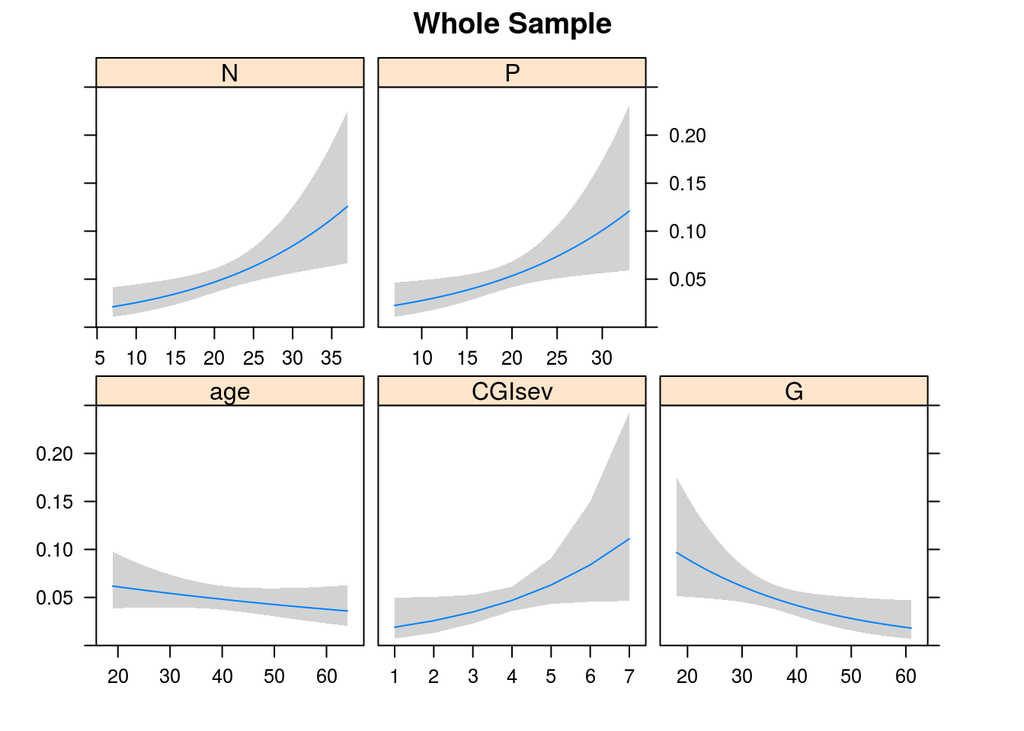

```r
plot(Predict(this.fit.whole, fun=plogis), main = "Whole Sample") # predicted values
```

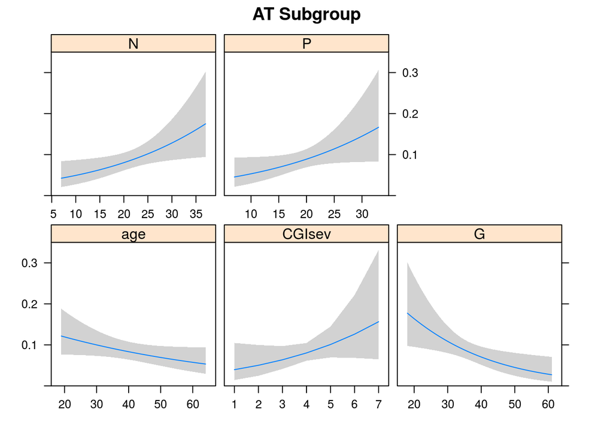

```r
plot(Predict(this.fit.AT, fun=plogis), main = "AT Subgroup") # predicted values
```

Notably, the uncertainty on the predicted probability of being TRS grows substantially for more extreme values of the variables P, N, G and CGIsev.

We can examine the bootstrap resampling logistic calibration statistics, for the whole population:

```r
# -- validation by logistic calibration
this.valid.whole <- rms::validate(this.fit.whole, method="boot", B=500) # bootstrapped validation
(this.valid.whole)
```

```
##           index.orig training    test optimism index.corrected   n
## Dxy           0.3770   0.3971  0.3513   0.0459          0.3311 500
## R2            0.0615   0.0715  0.0540   0.0175          0.0440 500
## Intercept     0.0000   0.0000 -0.2941   0.2941         -0.2941 500
## Slope         1.0000   1.0000  0.8847   0.1153          0.8847 500
## Emax          0.0000   0.0000  0.0880   0.0880          0.0880 500
## D             0.0215   0.0251  0.0187   0.0064          0.0151 500
## U            -0.0015  -0.0015  0.0004  -0.0019          0.0004 500
## Q             0.0230   0.0267  0.0184   0.0083          0.0147 500
## B             0.0538   0.0534  0.0541  -0.0007          0.0545 500
## g             0.7218   0.7740  0.6705   0.1034          0.6183 500
## gp            0.0380   0.0404  0.0357   0.0048          0.0332 500
```

And for the AT sub-population

```r
# -- validation by logistic calibration
this.valid.AT <- rms::validate(this.fit.AT, method="boot", B=500) # bootstrapped validation
(this.valid.AT)
```

```
##           index.orig training    test optimism index.corrected   n
## Dxy           0.2759   0.3071  0.2466   0.0605          0.2154 500
## R2            0.0459   0.0588  0.0369   0.0219          0.0240 500
## Intercept     0.0000   0.0000 -0.3744   0.3744         -0.3744 500
## Slope         1.0000   1.0000  0.8210   0.1790          0.8210 500
## Emax          0.0000   0.0000  0.1212   0.1212          0.1212 500
## D             0.0208   0.0271  0.0164   0.0107          0.0101 500
## U            -0.0026  -0.0026  0.0010  -0.0036          0.0010 500
## Q             0.0233   0.0297  0.0154   0.0143          0.0091 500
## B             0.0874   0.0868  0.0882  -0.0014          0.0889 500
## g             0.5725   0.6403  0.5059   0.1344          0.4381 500
## gp            0.0495   0.0548  0.0441   0.0107          0.0388 500
```

The Somers’ measure (Dxy) representing the model’s likely future predictive discrimination is poor, as are the unreliability index (U) and discrimination index (D).

Finally, a bootstrapped non-parametric bias-corrected calibration curve for the whole sample:

```r
# -- calibration curve
this.calib.whole <- rms::calibrate(this.fit.whole,
                           method="boot", B=500, bw = FALSE,
                           smoother = "lowess",
                           digits = NULL,
                           scat1d = FALSE) # model calibration
```

And for the AT subgroup:

```r
# -- calibration curve
this.calib.AT <- rms::calibrate(this.fit.AT,
                           method="boot", B=500, bw = FALSE,
                           smoother = "lowess",
                           digits = NULL,
                           scat1d = FALSE) # model calibration
```

Display the calibration plots:

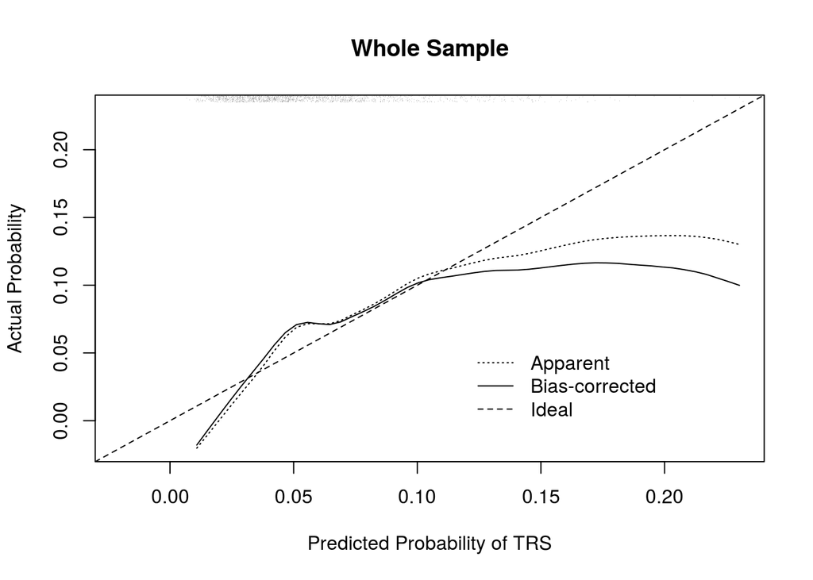

```
##
## n=1328   Mean absolute error=0.011   Mean squared error=0.00027
## 0.9 Quantile of absolute error=0.02
```

```r
plot(this.calib.whole, main = "Whole Sample", xlab = "Predicted Probability of TRS", ylab = "Actual Probability",
          subtitles = FALSE, legend = TRUE )
```

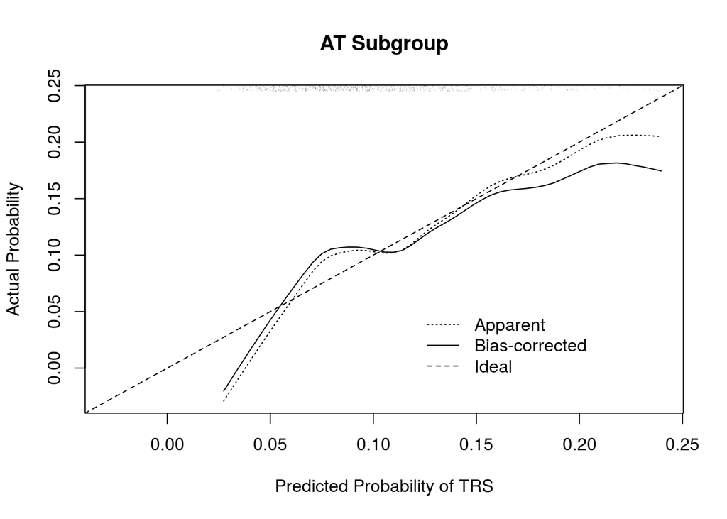

```
##
## n=779   Mean absolute error=0.014   Mean squared error=3e-04
## 0.9 Quantile of absolute error=0.026
```

```r
plot(this.calib.AT, main = "AT Subgroup", xlab = "Predicted Probability of TRS", ylab = "Actual Probability",
          subtitles = FALSE, legend = TRUE )
```

```r
  png( filename = "../DerivedData/calib_PANSS_Whole.png", width = 600, height = 600, units = "px", pointsize = 16 )
  plot(this.calib.whole, main = "Whole Sample", xlab = "Predicted Probability of TRS", ylab = "Actual Probability",
          subtitles = FALSE, legend = TRUE )
```

```
##
## n=1328   Mean absolute error=0.011   Mean squared error=0.00027
## 0.9 Quantile of absolute error=0.02
```

```r
  dev.off()
```

```r
  png( filename = "../DerivedData/calib_PANSS_AT.png", width = 600, height = 600, units = "px", pointsize = 16 )
  plot(this.calib.AT, main = "AT Subgroup", xlab = "Predicted Probability of TRS", ylab = "Actual Probability",
           subtitles = FALSE, legend = TRUE )
```

```
##
## n=779   Mean absolute error=0.014   Mean squared error=3e-04
## 0.9 Quantile of absolute error=0.026
```

```r
   dev.off()
```

The calibration plots shows systematic deviation of the predicted and actual probabilites for TRS status based on baseline psychopathology (adjusted for age), and we conclude that these are poorly predictive of future TRS status.

```r
cat("Execution time")
```

```
## Execution time
```

```r
Sys.time() - startTime
```

```
## Time difference of 42.2117 secs
```